# Reproducible Science - From theory to practice (by Roberto Garcia - INPE/BR)

### Overview

This notebook contains some practical approach programmed in Python in order to achieve [reproducible science](https://www.earthdatascience.org/courses/intro-to-earth-data-science/open-reproducible-science/get-started-open-reproducible-science/).

#### Opinions about Open and Reproducible Science

> Q1: Open Reproducible Science meaning:

> A: Open reproducible science means to me that science toolkit must be prepared, documented and disseminated in a way that it is accessible and clearly understandable to everyone. By toolkit I mean the complete set of elements of the research: data, methodology, and results.

> Q2: Example of a tool that fits Open Science:

> Jupyter notebook is a great example of tool that matches open science needs, it can mix code and textual and visual explanation of the research. Moreover, it can be shared to people.

> Q3: This notebook has a machine-readable name:

> A: In some manner, I think yes, because, besides it has no stardadization with respect to the words, it the words are ordinary ones, that can be easy found in a dictionary, thus it can be readable after some inference.
- Establishing a well-known e consensual format to apply along the construction of code
- Establishing a block documentation of functions
- Applying a tool to check the code concerning the format
- Using expressive variables and function names
- Using modular code if some block is executed multiple times
- Documenting the code using the right amount of comments, nor too small, nor too big

#### In order to make the science reproducible some approaches must be taken into account.

##### Making science easier to reproduce:

- Reproducible science is also about making the code easier to read and understand for people who didn't develop the code (a **clean** code).
- One way to achieve this is to apply some standardized rules for code formatting, such as [PEP 8](https://peps.python.org/pep-0008/).
- There are standards for Code Layout, Documentation, Naming, etc.
- All these standards can be **easily** checked and fixed by adding a extension to the IDE.
- How-to install and use the official Microsoft PEP 8 extension for MS Visual Studio Code (VS Code) can be found [here](https://github.com/Garcia-INPE/Tutorials/blob/main/Tut-PEP8_in_VSCode.md).

##### Making science explainable:

- Reproducible science is also about making the reseach easier to understand.
- One way to achieve this is to explain the methodology as accurately as possible, balancing short terms and sufficient explanations. Some actions include:
  - Using descriptive notebook file name and a main header that explains what will be presented.
  - Describing the data, such as:
    - Who takes the data.
    - Where the data were taken.
    - What the maximum temperature units are.
    - How the data are collected.
    - And don't forget to include a citation of the data.
  - Writing an overview of each sub analisys.
  - Including headlines and legend for figures
  - Making plots that have:
    - A title that explains where and when the data are from
    - x/y axis labels with **units** where appropriate
    - A legend where appropriate

# Research: Time Series analisys for Boulder / CO / USA

- The goal of this research is to compare the montly behaviour of the mininum and maximum temperature and precipitation for the period of 1900 to 2023 in Boulder, CO, USA.
- A few steps is necessary in order to complete a research:

### Doing research: Step 1 - Check the availability of the data

- According to an empirical knowledge acquired from [ESILL - Short Course](https://cu-esiil-edu.github.io/esiil-learning-portal/shortcourse/pages/00-course-overviews/shortcourse/00-home.html) 2024 edition, taught by [Nate Quarder](https://nquarder.github.io/) and [Elsa Culler](https://eculler.github.io/), the NOAA National Climatic Data Center (NOAA/NCEI) [Climate Data Online portal](https://www.ncei.noaa.gov/cdo-web/) has the target daily data from the [Global Historical Climate Network dataset (GHCND)](https://www.ncei.noaa.gov/cdo-web/search?datasetid=GHCND).
- Daily Summaries data from Boulder ground stations were chosen from [this form](https://www.ncei.noaa.gov/cdo-web/search?datasetid=GHCND), for the mentioned period.
- One should select the data source according to its needs, in this case, from [the station list provided](https://www.ncei.noaa.gov/cdo-web/datasets/GHCND/locations/CITY:US080001/detail#stationlist), a station which had the most of the chosen period of data covered was selected.
  - **Hint:** Play with the order of the columns to find what you want.
- A special care was taken in order to guarantee that the selected station had all climate variables (data types) used in this analisys ([Click in 'Station List' in this page](https://www.ncei.noaa.gov/cdo-web/datasets/GHCND/locations/CITY:US080001/detail)).

### Doing research: Step 2 - Getting the data

- Also according to [ESILL - Short Course](https://cu-esiil-edu.github.io/esiil-learning-portal/shortcourse/pages/00-course-overviews/shortcourse/00-home.html), there is an [API to access NCEI GHCND Data](https://www.ncei.noaa.gov/support/access-data-service-api-user-documentation).
- An **[API (Application Programming Interface)](https://en.wikipedia.org/wiki/API)** is a way for client programs (installed on a client computer) to establish communication with a server program (a **service** installed on a remote server computer), creating a [M2M (Machine to Machine)](https://en.wikipedia.org/wiki/Machine_to_machine) comunication.
- The intuition of communication is that we (the client) want to send a request message to the service and receive a response. For the NCEI GHCND API service, this request is a string representing a URL. This URL must be made up of special tags in which we specify the filtering option we want as a response.
- The metadata of the selected station are:

```
Selected station name:  LONGMONT 2 ESE, CO US
Network ID...........:  GHCND:USC00055116
Latitude/Longitude...:  40.16958°, -105.0774°
Elevation............:	1508.8 m
PERIOD OF RECORD
PRCP	Precipitation       1893-10-01	2024-04-28	100%
TMAX	Maximum temperature 1893-10-01	2024-04-29	100%
TMIN	Minimum temperature 1893-10-01	2024-04-29	100%
```

- In the cell below the URL is created according to the corresponding tags to match the station metadata.

```python
# Best practices
# Expressive variable name for the URL
# Respect the 79-character line limit
# Further lines aligned with opening delimiter
# Lines always break before tag separator
url = ("https://www.ncei.noaa.gov/access/services/data/v1"
               "?dataset=daily-summaries"
               "&dataTypes=PRCP,TMIN,TMAX"
               "&stations=USC00055116"
               "&startDate=1900-01-01"
               "&endDate=2023-12-31"
               "&includeStationName=true"
               "&includeStationLocation=1"
               "&units=metric")
# Observations
# 'includeLocation' means Lat and lon in the response
# Special care with the "units"

url    # Show the URL
```

```
'https://www.ncei.noaa.gov/access/services/data/v1?dataset=daily-summaries&dataTypes=PRCP,TMIN,TMAX&stations=USC00055116&startDate=1900-01-01&endDate=2023-12-31&includeStationName=true&includeStationLocation=1&units=metric'
```

```python
### Loading an well-known package to manipulate dataframes (tabular data)
import pandas as pd
# Downloading the original data to a Pandas DataFrame
df_ori = pd.read_csv(url, index_col="STATION")
```

### Doing research: Step 3 - Exploratory Data Analisys (EDA)

Lets know the data!

#### Configuring the output

```python
# The output of some examples below cuts out the content of lines
# making it difficult to read, expand the output width using:
pd.options.display.width = 500
```

#### Check if the data was imported into a pandas DataFrame

```python
type(df_ori)
```

```
pandas.core.frame.DataFrame
```

#### Showing 5 first and 5 last rows of the DataFrame

```python
df_ori
# Check if PRCP is in mm, TEMP fields are in Celsius (we especified
#    units=metric in our API request)
# Check the amount of rows and cols at the bottom (36961 rows × 8 cols)
# Note thar 'STATION' is an 'index col'
```

| STATION | NAME | LATITUDE | LONGITUDE | ELEVATION | DATE | PRCP | TMAX | TMIN |
| --- | --- | --- | --- | --- | --- | --- | --- | --- |
| USC00055116 | LONGMONT 2 ESE, CO US | 40.16958 | -105.0774 | 1508.8 | 1909-06-01 | 7.6 | 16.7 | 7.8 |
| USC00055116 | LONGMONT 2 ESE, CO US | 40.16958 | -105.0774 | 1508.8 | 1909-06-02 | 1.0 | 23.3 | 8.3 |
| USC00055116 | LONGMONT 2 ESE, CO US | 40.16958 | -105.0774 | 1508.8 | 1909-06-03 | 0.0 | 27.2 | 5.6 |
| USC00055116 | LONGMONT 2 ESE, CO US | 40.16958 | -105.0774 | 1508.8 | 1909-06-04 | 0.0 | 32.8 | 6.7 |
| USC00055116 | LONGMONT 2 ESE, CO US | 40.16958 | -105.0774 | 1508.8 | 1909-06-05 | 0.3 | 35.0 | 8.3 |
| ... | ... | ... | ... | ... | ... | ... | ... | ... |
| USC00055116 | LONGMONT 2 ESE, CO US | 40.16958 | -105.0774 | 1508.8 | 2023-12-27 | 0.0 | 6.7 | -1.1 |
| USC00055116 | LONGMONT 2 ESE, CO US | 40.16958 | -105.0774 | 1508.8 | 2023-12-28 | 0.0 | 10.6 | -8.9 |
| USC00055116 | LONGMONT 2 ESE, CO US | 40.16958 | -105.0774 | 1508.8 | 2023-12-29 | 0.0 | 10.0 | -8.9 |
| USC00055116 | LONGMONT 2 ESE, CO US | 40.16958 | -105.0774 | 1508.8 | 2023-12-30 | 0.0 | 14.4 | -6.1 |
| USC00055116 | LONGMONT 2 ESE, CO US | 40.16958 | -105.0774 | 1508.8 | 2023-12-31 | 0.0 | 13.3 | -5.0 |

36961 rows × 8 columns

#### Checking the type of each attribute (column)

```python
df_ori.dtypes
# Object can be strings
```

```
NAME          object
LATITUDE     float64
LONGITUDE    float64
ELEVATION    float64
DATE          object
PRCP         float64
TMAX         float64
TMIN         float64
dtype: object
```

#### DataFrame statistics

```python
descr = df_ori.describe()
descr  # The summarization is also a DataFame
# Take a look at the statistics for each meaninful attributes (columns)
# We can have good insights aboult the data here
```

|  | LATITUDE | LONGITUDE | ELEVATION | PRCP | TMAX | TMIN |
| --- | --- | --- | --- | --- | --- | --- |
| count | 3.696100e+04 | 3.696100e+04 | 3.696100e+04 | 36694.000000 | 36747.000000 | 36784.000000 |
| mean | 4.016958e+01 | -1.050774e+02 | 1.508800e+03 | 0.954698 | 18.118840 | 0.605638 |
| std | 1.170280e-11 | 6.363707e-11 | 8.703982e-10 | 3.800475 | 11.198193 | 9.542416 |
| min | 4.016958e+01 | -1.050774e+02 | 1.508800e+03 | 0.000000 | -50.600000 | -38.900000 |
| 25% | 4.016958e+01 | -1.050774e+02 | 1.508800e+03 | 0.000000 | 10.000000 | -6.100000 |
| 50% | 4.016958e+01 | -1.050774e+02 | 1.508800e+03 | 0.000000 | 18.900000 | 1.100000 |
| 75% | 4.016958e+01 | -1.050774e+02 | 1.508800e+03 | 0.000000 | 27.800000 | 8.900000 |
| max | 4.016958e+01 | -1.050774e+02 | 1.508800e+03 | 111.800000 | 41.100000 | 23.300000 |

#### Extracting data from the summary DataFrame

```python
# Use [row, col] notation to 'subselect' the data we want
print("TEMP records:",
      descr.loc["min", "TMIN"], "to",
      descr.loc["max", "TMAX"])
print("RAIN record.:",
      descr.loc["max", "PRCP"])
```

```
TEMP records: -38.9 to 41.1
RAIN record.: 111.8
```

#### Subselecting only the interesting columns

```python
# Let's create a subset of the Dataframe with only the 4 interesting
# columns (the date and its corresponding data)
df = df_ori[["DATE", "PRCP", "TMAX", "TMIN"]]
# And show it
df
```

| STATION | DATE | PRCP | TMAX | TMIN |
| --- | --- | --- | --- | --- |
| USC00055116 | 1909-06-01 | 7.6 | 16.7 | 7.8 |
| USC00055116 | 1909-06-02 | 1.0 | 23.3 | 8.3 |
| USC00055116 | 1909-06-03 | 0.0 | 27.2 | 5.6 |
| USC00055116 | 1909-06-04 | 0.0 | 32.8 | 6.7 |
| USC00055116 | 1909-06-05 | 0.3 | 35.0 | 8.3 |
| ... | ... | ... | ... | ... |
| USC00055116 | 2023-12-27 | 0.0 | 6.7 | -1.1 |
| USC00055116 | 2023-12-28 | 0.0 | 10.6 | -8.9 |
| USC00055116 | 2023-12-29 | 0.0 | 10.0 | -8.9 |
| USC00055116 | 2023-12-30 | 0.0 | 14.4 | -6.1 |
| USC00055116 | 2023-12-31 | 0.0 | 13.3 | -5.0 |

36961 rows × 4 columns

#### Adjusting the DataFrame index

```python
# Let's drop the index created for STATION (useless) and make DATE
#    to be the new index (more meaninful)
# Let's also auto reassign the result to df2 itself with 'inplace'
df.set_index("DATE", inplace=True)
df
```

| DATE | PRCP | TMAX | TMIN |
| --- | --- | --- | --- |
| 1909-06-01 | 7.6 | 16.7 | 7.8 |
| 1909-06-02 | 1.0 | 23.3 | 8.3 |
| 1909-06-03 | 0.0 | 27.2 | 5.6 |
| 1909-06-04 | 0.0 | 32.8 | 6.7 |
| 1909-06-05 | 0.3 | 35.0 | 8.3 |
| ... | ... | ... | ... |
| 2023-12-27 | 0.0 | 6.7 | -1.1 |
| 2023-12-28 | 0.0 | 10.6 | -8.9 |
| 2023-12-29 | 0.0 | 10.0 | -8.9 |
| 2023-12-30 | 0.0 | 14.4 | -6.1 |
| 2023-12-31 | 0.0 | 13.3 | -5.0 |

36961 rows × 3 columns

#### Let's check missing data (VERY! important in EDA)

```python
print("Checking missind data with isnull()\n", df.isnull().sum())
print("Checking missind data with isna()\n", df.isna().sum())
# These functions are the same, isna() is an alias to isnull()
# If the function print() were not used, only the last line would be
#    printed for the output
```

```
Checking missind data with isnull()
 PRCP    267
TMAX    214
TMIN    177
dtype: int64
Checking missind data with isna()
 PRCP    267
TMAX    214
TMIN    177
dtype: int64
```

#### Let's check which rows have at least one missing data

```python
null_mask = df.isnull().any(axis=1)
null_rows = df[null_mask]
print(null_rows)
# 537 rows
```

```
            PRCP  TMAX  TMIN
DATE
1909-09-01   NaN  28.3  12.8
1909-09-02   NaN  32.8  16.1
1909-09-08   NaN  28.3  10.0
1909-09-09   NaN  27.8   8.3
1909-09-10   NaN  29.4  15.0
...          ...   ...   ...
2018-01-26   0.0   NaN   NaN
2018-08-16   0.0   NaN   NaN
2018-11-16   0.0   NaN   NaN
2019-01-10   0.0   NaN   NaN
2023-01-06   0.0   NaN   NaN

[537 rows x 3 columns]
```

#### IMPORTANT! MISSING DATA MANIPULATION

We faced with a very common impasse in data science, **how to handle missing data**. Some options for this case would be:

- Complete the data with data from another station
- Complete the data with interpolation techniques
- And eliminate missing data

In this case, to speed up the research process, the lines that contain any missing data will be eliminated.

```python
df_ok = df[~null_mask]   # from the previous code cell
print(df_ok)
#rows_ori - row_null = rows_ok
len(df) - len(null_rows)    # 36961 - 537 = 36424
```

```
            PRCP  TMAX  TMIN
DATE
1909-06-01   7.6  16.7   7.8
1909-06-02   1.0  23.3   8.3
1909-06-03   0.0  27.2   5.6
1909-06-04   0.0  32.8   6.7
1909-06-05   0.3  35.0   8.3
...          ...   ...   ...
2023-12-27   0.0   6.7  -1.1
2023-12-28   0.0  10.6  -8.9
2023-12-29   0.0  10.0  -8.9
2023-12-30   0.0  14.4  -6.1
2023-12-31   0.0  13.3  -5.0

[36424 rows x 3 columns]
```

```
36424
```

#### Plotting the cleaned DataFrame

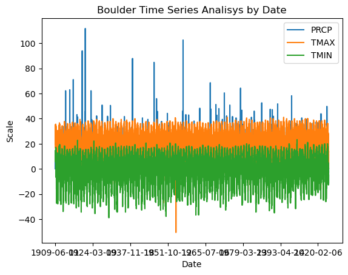

```python
df_ok.plot(title="Boulder Time Series Analisys by Date",
           xlabel="Date",
           ylabel="Scale")
# The plot has a very weird output:
#   - Y-axis scale is not good (mixings data scales)
#   - X-axis labels are not clear
```

#### Summarizing data monthly mean

```python
# Summarizing must respect the year and month)
# Pandas has a special function for this
df_group = df_ok.groupby([df_ok.index.year, df_ok.index.month]).mean()

# ERROR: The index column (DATE) is not a Date object but a String
```

```
---------------------------------------------------------------------------
AttributeError                            Traceback (most recent call last)
Cell In[86], line 3
      1 # Summarizing must respect the year and month)
      2 # Pandas has a special function for this
----> 3 df_group = df_ok.groupby([df_ok.index.year, df_ok.index.month]).mean()
      5 # ERROR: The index column (DATE) is not a Date object but a String

AttributeError: 'Index' object has no attribute 'year'
```

#### Converting the index to DateTime

```python
df_ok.index = pd.to_datetime(df_ok.index)
type(df_ok.index)
```

```
pandas.core.indexes.datetimes.DatetimeIndex
```

#### Trying to summarize the DataFrame by month and year again

```python
df_group = df_ok.groupby([df_ok.index.year, df_ok.index.month]).mean()
# And show it
df_group
```

| DATE | DATE | PRCP | TMAX | TMIN |
| --- | --- | --- | --- | --- |
| 1909 | 6 | 1.276667 | 27.546667 | 9.486667 |
|  | 7 | 0.600000 | 31.148387 | 12.903226 |
|  | 8 | 0.629032 | 31.438710 | 12.567742 |
|  | 9 | 7.085714 | 20.857143 | 10.414286 |
|  | 10 | 0.180645 | 20.793548 | -0.238710 |
| ... | ... | ... | ... | ... |
| 2023 | 8 | 1.754839 | 29.945161 | 14.012903 |
|  | 9 | 0.900000 | 27.236667 | 9.386667 |
|  | 10 | 0.451613 | 19.119355 | 2.448387 |
|  | 11 | 0.420000 | 13.773333 | -3.413333 |
|  | 12 | 0.206452 | 9.912903 | -4.877419 |

1214 rows × 3 columns

#### Rechecking the plot

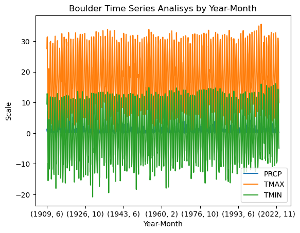

```python
df_group.plot(title="Boulder Time Series Analisys by Year-Month",
              xlabel="Year-Month",
              ylabel="Scale")
# Still a weind plot!
```

#### Spliting data and shared x-axis

```
array([<Axes: xlabel='Year', ylabel='Scale'>,
       <Axes: xlabel='Year', ylabel='Scale'>,
       <Axes: xlabel='Year', ylabel='Scale'>], dtype=object)
```

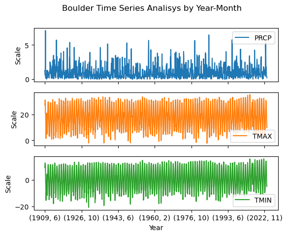

```python
df_group.plot(
    subplots=True,
    title="Boulder Time Series Analisys by Year-Month",
    xlabel="Year",
    ylabel="Scale")
```

#### How if we group it by year?

```python
df_grp_year = df_ok.groupby([df_ok.index.year]).mean()
df_grp_year
```

| DATE | PRCP | TMAX | TMIN |
| --- | --- | --- | --- |
| 1909 | 0.902094 | 21.100524 | 2.823037 |
| 1910 | 0.394326 | 15.619858 | -3.743262 |
| 1911 | 0.598619 | 18.079558 | -0.014088 |
| 1912 | 1.298857 | 15.447714 | -0.978286 |
| 1913 | 1.193315 | 16.598886 | -0.734819 |
| ... | ... | ... | ... |
| 2019 | 1.299451 | 17.505220 | 1.601648 |
| 2020 | 0.937432 | 19.324863 | 2.424590 |
| 2021 | 1.099726 | 19.115890 | 2.783836 |
| 2022 | 1.060822 | 18.547123 | 1.912329 |
| 2023 | 1.474451 | 18.104396 | 2.550824 |

103 rows × 3 columns

```python
#### Plotting by year
```

```
array([<Axes: xlabel='Year', ylabel='Scale'>,
       <Axes: xlabel='Year', ylabel='Scale'>,
       <Axes: xlabel='Year', ylabel='Scale'>], dtype=object)
```

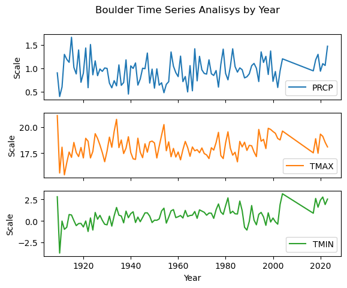

```python
df_grp_year.plot(
    subplots=True,
    title="Boulder Time Series Analisys by Year",
    xlabel="Year",
    ylabel="Scale")
```

# **THIS ISN’T THE END!** 😄

## From now on we can continue as we wish

#### Have Fun!

```python
%%capture
%%bash
jupyter nbconvert Reproducible_Science_From_Theory_To_Practice.ipynb --to markdown
jupyter nbconvert Reproducible_Science_From_Theory_To_Practice.ipynb --to html
```